# Multiple correlations in Stan

Michele Scandola

2021-02-07

```r
library(knitr)
library(ggplot2)
library(ggExtra)
```

In Bayesian Statistics a lot of packages are devoted in applying the most complex and fascinating, model-based, statistics.

Something that is less covered are base-level statistics, such as correlation.

This post is based on **Rasmus Bååth**’s robust correlation model in JAGS, and **Adrian Baez-Ortega** conversion in Stan.

For their original contributions, see:

- [Bayesian correlation in JAGS](http://www.sumsar.net/blog/2013/08/bayesian-estimation-of-correlation/)
- [Robust Bayesian Correlation in JAGS](http://www.sumsar.net/blog/2013/08/robust-bayesian-estimation-of-correlation/)
- [Robust Bayesian Correlation in Stan](https://github.com/baezortega/bayes/tree/master/robust_correlation)

In this post, I start from the **Rasmus Bååth** and **Adrian Baez-Ortega** work, to extend it later, by adding the possibility to obtain Savage-Dickey density ratio Bayes Factors and the possibility to compute multiple correlation with a single function (instead to compute many one-to-one correlations, saving time and computational resources).

## The Basic Idea

In order to compute the correlation between two normally-distributed variables

$y \sim \mathcal{N}(\mu_y,\sigma^2_y)$ $x \sim \mathcal{N}(\mu_x,\sigma^2_x)$

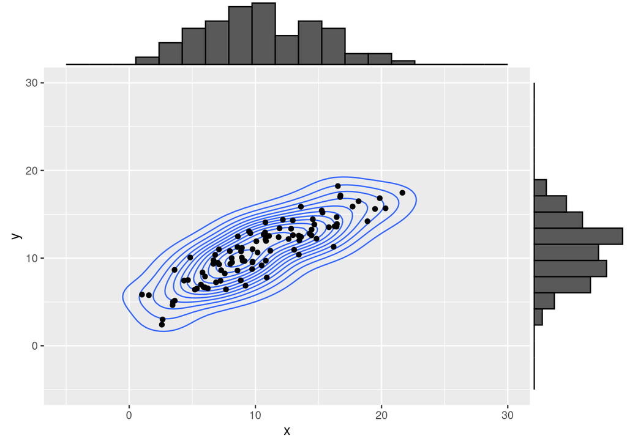

```r
set.seed(4)

x <- rnorm(100, mean = 10, sd = 5)
y <- x * 0.7 + rnorm(100, mean = 3.7, sd = pi/2)

dat <- data.frame(x , y)

g1 <- ggplot( dat, aes(y = y, x = x) )+
  geom_density_2d()+
  geom_point()+
  xlim(c(-5, 30))+
  ylim(c(-5, 30))

ggMarginal(g1, type = "histogram", bins = 20)
```

The brilliant idea behind this is that two variables that correlate they obviously share some covariance, that is composed by the variances and their correlation.

## From the covariance matrix to the correlation matrix

Therefore, these two independent-but-correlating normal distributions, can be seen as a multinormal distribution with their own variance-covariance matrix (a.k.a covariance matrix).

Thus, our dataset becomes:

$[y, x] \sim \mathcal{MN}(M, \Omega)$

where $M = [\mu_y, \mu_x]$ is the vector of the means, and

$$\Omega =
\left[\begin{array}{cc}
\sigma_y^2 & \sigma_x \sigma_y \rho_{x,y}\\
\sigma_x \sigma_y \rho_{x,y} & \sigma_x^2
\end{array}\right]$$

(in order to simplify the notation, $\sigma$ will be the variance and not, as usual, the standard deviation).

The variance-covariance matrix $\Omega$ can be computed starting from the diagonal matrix of variances $\Sigma$ and the correlation matrix $R$

$$\Omega = \Sigma \times R \times \Sigma =
\left[\begin{array}{cc}
\sigma_y & 0\\
0 & \sigma_x
\end{array}\right] \times
\left[\begin{array}{cc}
1 & \rho_{x,y}\\
\rho_{x,y} & 1
\end{array}\right] \times
\left[\begin{array}{cc}
\sigma_y & 0\\
0 & \sigma_x
\end{array}\right]$$

Just to confirm that everything its written here is correct, some math:

```r
# std dev for    x  y    with square-elevation to have the variances
Sigma <- diag( c(5, pi/2)^2 )

kable(Sigma, caption = "Variances diagonal matrix")
```

Variances diagonal matrix

| 25 | 0.000000 |
| --- | --- |
| 0 | 2.467401 |

```r
R <- matrix( c(1  , 0.7,
               0.7, 1  ),
             byrow = TRUE,
             ncol = 2 )

kable(R, caption = "Correlation matrix")
```

Correlation matrix

| 1.0 | 0.7 |
| --- | --- |
| 0.7 | 1.0 |

```r
kable(Sigma %*% R %*% Sigma, digits = 2, caption = "Covariance matrix")
```

Covariance matrix

| 625.00 | 43.18 |
| --- | --- |
| 43.18 | 6.09 |

```r
kable(cov2cor(Sigma %*% R %*% Sigma),
      caption = "If everything is correct, we should have our correlation matrix back")
```

If everything is correct, we should have our correlation matrix back

| 1.0 | 0.7 |
| --- | --- |
| 0.7 | 1.0 |

Well, yes, nothing spectacular, but at least we are sure that the math is OK.

### The prior distributions from the **Rasmus Bååth** work and a normal Bayesian correlation

In order to obtain a posterior distribution for $\rho_{x,y}$, in our Bayesian code we should estimate the posterior distribution for:

- $M$, that for **Rasmus Bååth** suggestions, each element can be non-informative $\mu \sim \mathcal{N}(0, 1000)$
- The $\Sigma$ diagonal matrix, that with an non-informative prior each element would be: $\sigma \sim \mathcal{U}(0, 1000)$
- $rho$, whose non-informative distribution would be $\rho \sim \mathcal{U}(-1, 1)$

  Therefore, the Stan code is:

```r
stancode1 <-"
data {
    int<lower=1> N;  // number of observations
    vector[2] x[N];  // input data: rows are observations, columns are the two variables
}

parameters {
    vector[2] mu;                 // means vector
    real<lower=0> sigma[2];       // variances vector
    real<lower=-1, upper=1> rho;    // correlation coefficient
}

transformed parameters {
    // Covariance matrix
    cov_matrix[2] cov = [[      sigma[1] ^ 2       , sigma[1] * sigma[2] * rho],
                         [sigma[1] * sigma[2] * rho,       sigma[2] ^ 2       ]];
}

model {
    // Likelihood
    // Bivariate Student's t-distribution instead of normal for robustness
    x ~ multi_normal(mu, cov);

    // Noninformative priors on all parameters
    sigma ~ uniform(0, 1000);
    mu ~ normal(0, 1000);
    rho ~ uniform(-1,1);//non informative prior between -1 and 1
}

generated quantities {
    // Random samples from the estimated bivariate normal distribution (for assessment of fit)
    vector[2] x_rand;
    x_rand = multi_normal_rng(mu, cov);
}"
```

… and to call it, you just need to prepare you data list and run the analysis

```r
library(rstan)
```

```r
library(bayesplot)
data.list <- list(
  x = cbind( x, y ),
  N = nrow( dat )
)

mdlCor1 <- stan(
  model_code = stancode1,
  data = data.list,
  pars = "rho",
  refresh = 0
)
```

```
## Trying to compile a simple C file
```

[output not shown]

```r
kable( summary(mdlCor1)[[1]] , digits = 3,
       caption = "Posterior distribution for the rho parameter")
```

Posterior distribution for the rho parameter

|  | mean | se_mean | sd | 2.5% | 25% | 50% | 75% | 97.5% | n_eff | Rhat |
| --- | --- | --- | --- | --- | --- | --- | --- | --- | --- | --- |
| rho | 0.879 | 0.001 | 0.023 | 0.827 | 0.866 | 0.881 | 0.896 | 0.919 | 1868.711 | 1.000 |
| lp__ | -298.518 | 0.039 | 1.569 | -302.417 | -299.336 | -298.207 | -297.344 | -296.436 | 1581.159 | 1.002 |

```r
mcmc_combo(
  mdlCor1,
  pars = "rho"
)
```

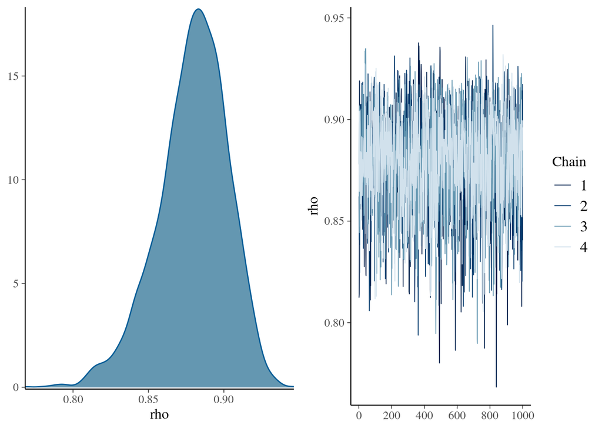

Density and trace plot for our rho parameter of the first bayesian correlation in stan

Ok, so here we have some results.

I am not showing you how to check if the model is ok, etc… etc… **Rasmus Bååth** did a great job, so you might want to take a look at his page.

## The Bayesian Robust Correlation

Anyway, the best part of the **Rasmus Bååth** work was to enhance the correlation concept towards a robust correlation that, at the best of my knowledge, has no similarities with any “traditional” correlation coefs.

> Robust: more resistent to outliers

Therefore, as it is usually done to have robust linear models in Bayesian Statistics, the prior for our observed variables is not anymore a Normal distribution, but a Student’s t distribution with unknown $\nu$ degrees of freedom.

The Student’s t distribution has strong connections with the Normal distribution but, changing its degrees of freedom ($\nu$), the tails can allow more probability at the extremes (smaller degrees of freedom), or less probability (larger degrees of freedom). It is known that a Student’s t distribution with $\nu \to + \inf$ is a Normal distribution.

Smaller $\nu$ it is allowed that extreme values are further from the center of the distribution (namely, the $\mu$ of the Student’s t distribution is more resilient to outliers), while greater $\nu$ values makes $\mu$ more dependent to extreme values.

Consequently, in the code we changed these prior distributions:

```r
stancode2 <-"
data {
    int<lower=1> N;  // number of observations
    vector[2] x[N];  // input data: rows are observations, columns are the two variables
}

parameters {
    vector[2] mu;                 // mean vector of the marginal t distributions
    real<lower=0> sigma[2];       // variance vector of the marginal t distributions
    real<lower=1> nu;             // degrees of freedom of the marginal t distributions
    real<lower=-1, upper=1> rho;  // correlation coefficient
}

transformed parameters {
    // Covariance matrix
    cov_matrix[2] cov = [[      sigma[1] ^ 2       , sigma[1] * sigma[2] * rho],
                         [sigma[1] * sigma[2] * rho,       sigma[2] ^ 2       ]];
}

model {
    // Likelihood
    // Bivariate Student's t-distribution instead of normal for robustness
    x ~ multi_student_t(nu, mu, cov);

    // Noninformative priors on all parameters
    sigma ~ uniform(0, 1000);
    mu ~ normal(0, 1000);
    nu ~ uniform(0,1000);
    rho ~ uniform(-1,1);//non informative prior between -1 and 1
}

generated quantities {
    // Random samples from the estimated bivariate t-distribution (for assessment of fit)
    vector[2] x_rand;
    x_rand = multi_student_t_rng(nu, mu, cov);
}
"
```

and these are the new results:

```r
mdlCor2 <- stan(
  model_code = stancode2,
  data = data.list,
  pars = c("rho","nu"),
  refresh = 0
)
```

```
## Trying to compile a simple C file
```

[output not shown]

```r
kable( summary(mdlCor2)[[1]] , digits = 3,
       caption = "Posterior distribution for the rho and nu parameters")
```

Posterior distribution for the rho and nu parameters

|  | mean | se_mean | sd | 2.5% | 25% | 50% | 75% | 97.5% | n_eff | Rhat |
| --- | --- | --- | --- | --- | --- | --- | --- | --- | --- | --- |
| rho | 0.878 | 0.001 | 0.023 | 0.825 | 0.865 | 0.879 | 0.894 | 0.916 | 328.758 | 1.020 |
| nu | 514.408 | 13.514 | 273.050 | 54.721 | 284.376 | 512.978 | 752.251 | 973.033 | 408.216 | 1.019 |
| lp__ | -362.048 | 0.070 | 1.856 | -366.584 | -363.054 | -361.739 | -360.725 | -359.387 | 709.467 | 1.012 |

```r
mcmc_combo(
  mdlCor2,
  pars = c("rho", "nu")
)
```

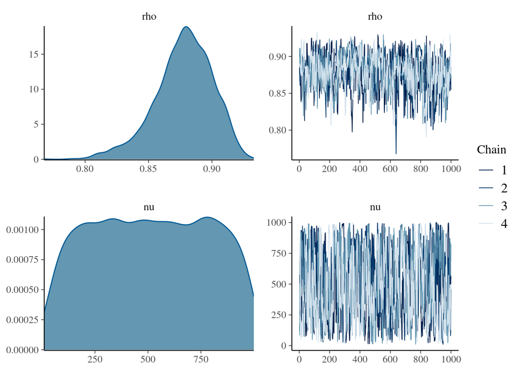

Well, the two distributions are directly coming from random normal distributions, so there should not be big differences between this robust and the non-robust version.

However, here we gain the $\nu$ (nu) parameter, that as **Krushcke** said (in one of its books), it might be an index of normality of our distributions.

We all know that a Student’s t distribution with $\Inf$ degrees of freedom is basically the same as a Normal distribution. Therefore, if our $\nu$ distribution stretched toward small numbers it should be an index that our distributions are not parametrically distributed (in fact, a Cauchy distribution is a Student’s t distribution with 1 degree of freedom).

## The Bayesian Robust Correlation: degrees of freedom dependent from the number of observations

However, why should $\nu$ be unknown?

We all know that, for an extension of the central limit theorem, the biggest the sample, the more “certain” is the mean.

> Central Limit Theorem: when independent random variables are added, their properly normalized sum tends toward a normal distribution

Therefore, it might be reasonable to establish some relation between the number of observations and $\nu$.

Here it starts my personal contribution, that you can also find in my [github](https://github.com/michelescandola).

I have decided that the number of degrees of freedom are equal to the number of observations divided by 10 plus 1.

```r
stancode3 <-"
data {
    int<lower=1> N;  // number of observations
    vector[2] x[N];  // input data: rows are observations, columns are the two variables
}

parameters {
    vector[2] mu;                 // mean vector of the marginal t distributions
    real<lower=0> sigma[2];       // variance vector of the marginal t distributions
    real<lower=-1, upper=1> rho;  // correlation coefficient
}

transformed parameters {
    // degrees of freedom of the marginal t distributions
    real<lower=1> nu = (N / 10.0) + 1;

    // Covariance matrix
    cov_matrix[2] cov = [[      sigma[1] ^ 2       , sigma[1] * sigma[2] * rho],
                         [sigma[1] * sigma[2] * rho,       sigma[2] ^ 2       ]];
}

model {
    // Likelihood
    // Bivariate Student's t-distribution instead of normal for robustness
    x ~ multi_student_t(nu, mu, cov);

    // Noninformative priors on all parameters
    sigma ~ uniform(0, 1000);
    mu ~ normal(0, 1000);
    rho ~ uniform(-1,1);//non informative prior between -1 and 1
}

generated quantities {
    // Random samples from the estimated bivariate t-distribution (for assessment of fit)
    vector[2] x_rand;
    x_rand = multi_student_t_rng(nu, mu, cov);
}
"

mdlCor3 <- stan(
  model_code = stancode3,
  data = data.list,
  pars = "rho",
  refresh = 0
)
```

```
## Trying to compile a simple C file
```

[output not shown]

```r
kable( summary(mdlCor3)[[1]] , digits = 3,
       caption = "Posterior distribution for the rho parameters")
```

Posterior distribution for the rho parameters

|  | mean | se_mean | sd | 2.5% | 25% | 50% | 75% | 97.5% | n_eff | Rhat |
| --- | --- | --- | --- | --- | --- | --- | --- | --- | --- | --- |
| rho | 0.878 | 0.001 | 0.024 | 0.824 | 0.863 | 0.880 | 0.895 | 0.919 | 1912.122 | 1.001 |
| lp__ | -370.810 | 0.040 | 1.611 | -374.715 | -371.660 | -370.476 | -369.624 | -368.725 | 1643.435 | 1.001 |

```r
mcmc_combo(
  mdlCor3,
  pars = "rho"
)
```

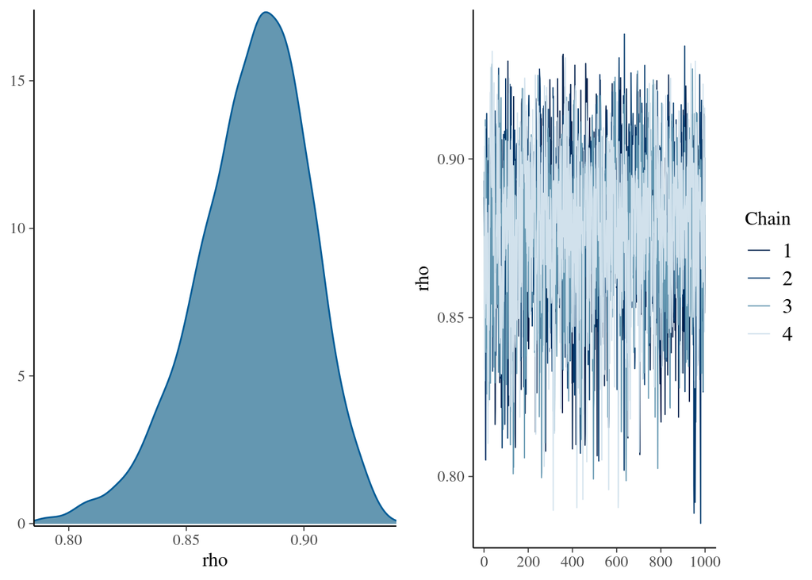

[Download the Stan code](https://github.com/michelescandola/BayesianCorrelations/blob/main/robust_correlation_dog_from_sample_size.stan)

## The Bayesian Robust Correlation: computing the Savage-Dickey density ratio

Until know the model was based on non-informative distributions, and our conclusions can be based on Credible Intervals (a.k.a Equally-Tailed Intervals), or in High Posterior Density Intervals.

But what we can do to compute Bayes Factors?

Among the simplest solutions, we can use the Savage-Dickey density ratio.

> Savage-Dickey Density Ratio: the ratio between the density distributions of the posterior distribution and the prior distribution, with $\theta = 0$. Savage-Dickey’s $BF_{01} = Pr(\theta = 0 | D, H_0) / Pr(\theta = 0 | H_0)$

The idea is the following:

Assuming that our $H_0$ distribution is distributed around our “null” value (usually the zero), this should have the peak exactly on that value (otherwise, our null distribution is not a null distribution).

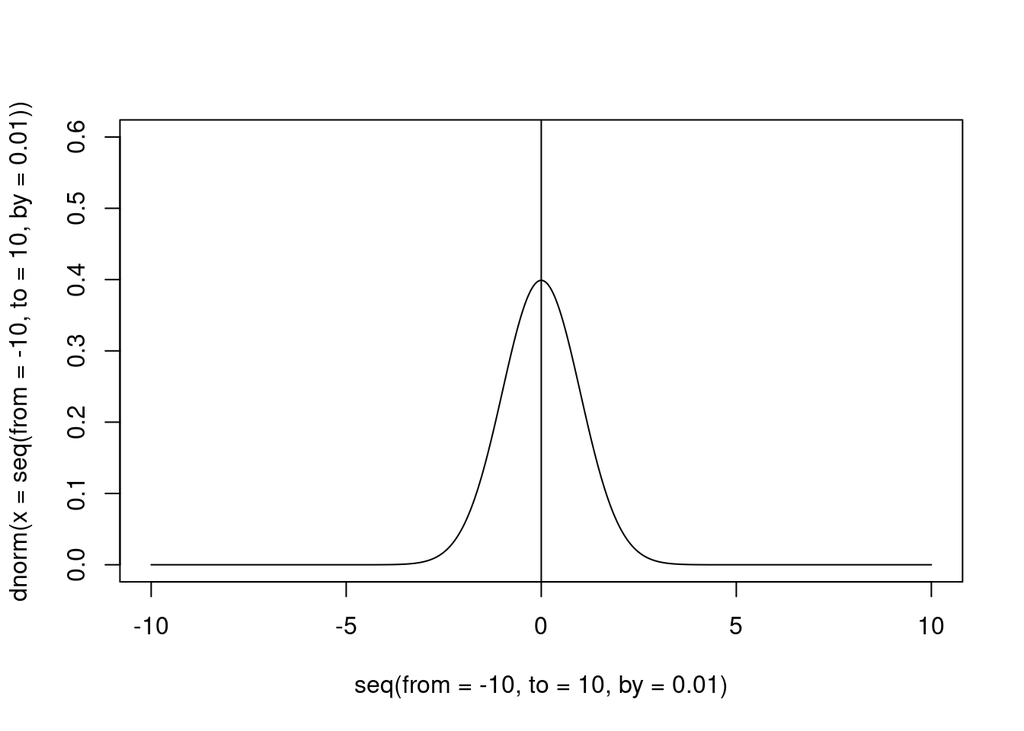

An example of informative prior for the null hypothesis

```r
plot(
  y = dnorm(x = seq(from = -10, to = 10, by = 0.01)),
  x = seq(from = -10, to = 10, by = 0.01),
  type = "l",
  ylim = c(0, 0.6)
)
abline(v = 0)
```

If our data are not distributed according our $H_0$ distribution, the peak of the posterior distribution should be elsewhere, and the elevation of the posterior distribution at the “null” value should be less than the peak at the same position for the $H_0$ distribution.

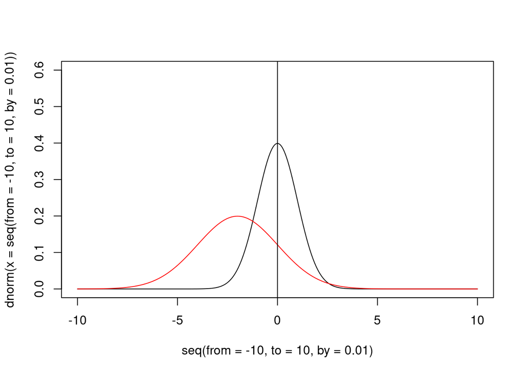

The prior and the posterior (red) distribution

```r
plot(
  y = dnorm(x = seq(from = -10, to = 10, by = 0.01)),
  x = seq(from = -10, to = 10, by = 0.01),
  type = "l",
  ylim = c(0, 0.6)
)
points(
  y = dnorm(x = seq(from = -10, to = 10, by = 0.01),
            mean = -2, sd = 2),
  x = seq(from = -10, to = 10, by = 0.01),
  col = "red",
  type = "l"
)
abline(v = 0)
```

In this case, the Savage-Dickey $BF_{01}$ is 0.3, that is obviously in favour of the alternative hypothesis.

However, to compute the $BF_{10}$ we could compute the reciprocal: 3.3.

OK. So far, so good.

As you have already noticed, we cannot rely anymore on non-informative prior distributions, at least for the $\rho$ parameter.

Now, we should think to the possible informative prior for the correlation.

A natural candidate is the Beta distribution ($\mathcal{B}(\alpha, \beta) \rightarrow [0,1]$):

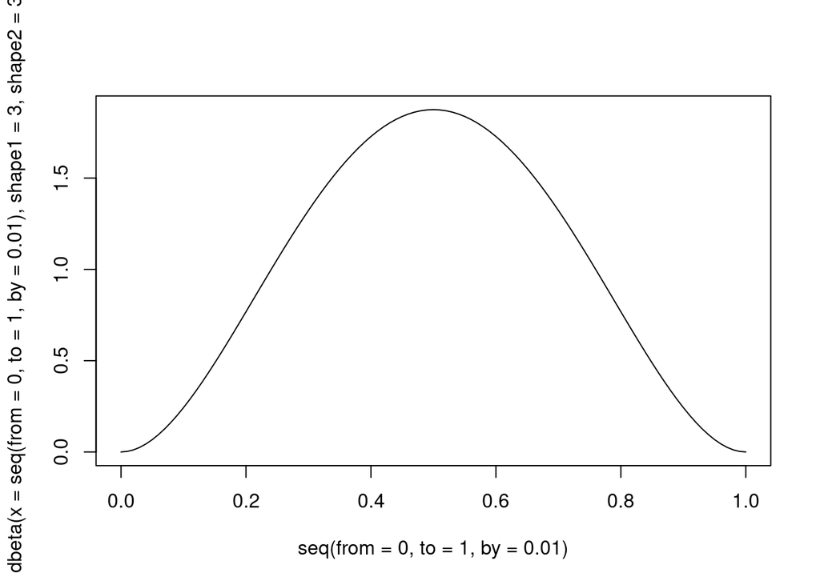

A Beta distribution with alpha and beta = 3

```r
plot(
  y = dbeta(x = seq(from = 0, to = 1, by = 0.01),
            shape1 = 3, shape2 = 3),
  x = seq(from = 0, to = 1, by = 0.01),
  type = "l"
)
```

but we should stretch it in order to have a [-1, 1] range.

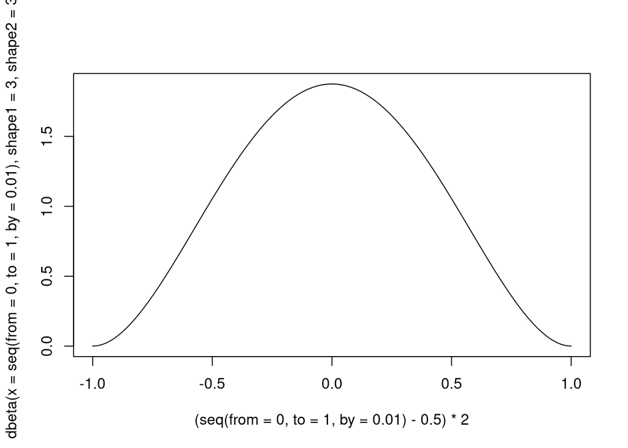

A Beta distribution with alpha and beta = 3

```r
plot(
  y = dbeta(x = seq(from = 0, to = 1, by = 0.01),
            shape1 = 3, shape2 = 3),
  x = (seq(from = 0, to = 1, by = 0.01) - 0.5) * 2,
  type = "l"
)
```

Therefore, what we will do is to use a Beta distribution, with the two parameters equal to 3, in order to have high density when $\theta$ is equal to the “null” value. For a $\mathcal{B}$ distribution this value is not 0, but 0.5, because this probability distribution is defined in $[0,1]$, and not in $[-\inf, +\inf]$, as it happens in distributions such as the Student’s t and the Gaussian ones.

Therefore, in the code below, I have declared the `rh` variable in the `parameters` block, set its prior distribution as a $\mathcal{B}(3,3)$ in the `model` block, and converted it in the `rho` parameter, necessary to compute the `cov` matrix in the `transformed parameters` block, necessary for the multiple Student’s t distribution.

Finally, I have computed the $BF_{10}$ on the `rh` parameter, with a $\theta = 0.5$, while we can use the `rho` parameter to get Credible Intervals and all these statistics.

$BF_{10} = \frac{Pr(\theta = 0.5 | D, H_0 = \mathcal{B}(\alpha = 3, \beta = 3))}{Pr(\theta = 0.5 | H_0 = \mathcal{B}(\alpha = 3, \beta = 3))}$

```r
library(logspline)

stancode4 <-"
data {
    int<lower=1> N;  // number of observations
    vector[2] x[N];  // input data: rows are observations, columns are the two variables
}

parameters {
    vector[2] mu;                 // locations of the marginal t distributions
    real<lower=0> sigma[2];       // scales of the marginal t distributions
    real<lower=1> nu;             // degrees of freedom of the marginal t distributions
    real<lower=0, upper=1> rh;  // correlation coefficient
}

transformed parameters {
    //correlation index rh is scaled to be within -1 and 1
    real<lower=-1, upper=1> rho = 2*(rh-0.5);
    // Covariance matrix
    cov_matrix[2] cov = [[      sigma[1] ^ 2       , sigma[1] * sigma[2] * rho],
                         [sigma[1] * sigma[2] * rho,       sigma[2] ^ 2       ]];
}

model {
    // Likelihood
    // Bivariate Student's t-distribution instead of normal for robustness
    x ~ multi_student_t(nu, mu, cov);

    // Noninformative priors on all parameters
    sigma ~ normal(0, 1000);
    mu ~ normal(0, 1000);
    nu ~ uniform(0, 1000);
    rh ~ beta(3, 3);//non informative prior between 0 and 1
}

generated quantities {
    // Random samples from the estimated bivariate t-distribution (for assessment of fit)
    vector[2] x_rand;
    x_rand = multi_student_t_rng(nu, mu, cov);
}
"

mdlCor4 <- stan(
  model_code = stancode4,
  data = data.list,
  pars = c("rho","rh"),
  refresh = 0
)
```

```
## Trying to compile a simple C file
```

[output not shown]

```r
kable( summary(mdlCor4)[[1]] , digits = 3,
       caption = "Posterior distribution for the rho and rh parameters")
```

Posterior distribution for the rho and rh parameters

|  | mean | se_mean | sd | 2.5% | 25% | 50% | 75% | 97.5% | n_eff | Rhat |
| --- | --- | --- | --- | --- | --- | --- | --- | --- | --- | --- |
| rho | 0.872 | 0.002 | 0.025 | 0.815 | 0.857 | 0.874 | 0.890 | 0.915 | 260.699 | 1.022 |
| rh | 0.936 | 0.001 | 0.013 | 0.907 | 0.929 | 0.937 | 0.945 | 0.957 | 260.699 | 1.022 |
| lp__ | -368.320 | 0.078 | 1.792 | -372.699 | -369.292 | -368.046 | -366.987 | -365.741 | 529.762 | 1.007 |

```r
mcmc_combo(
  mdlCor4,
  pars = c("rho", "rh")
)
```

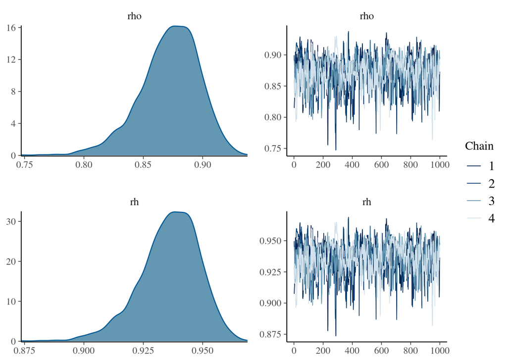

```r
rh_logspl <- logspline( extract( mdlCor4 , pars = "rh") )
BF10      <- dbeta(0.5, 3, 3) / dlogspline(0.5, rh_logspl)
```

This is the version with unknown degrees of freedom [download the Stan code](https://github.com/michelescandola/BayesianCorrelations/blob/main/robust_correlation_dog_unknown_informed_prior.stan)

Version with degrees of freedom coming from the sample size [download the Stan code](https://github.com/michelescandola/BayesianCorrelations/blob/main/robust_correlation_dog_from_sample_size_informative_prior.stan)

Version with a Multi Normal distribution instead of a Multi Student’s t distribution (normal correlation) [download the Stan code](https://github.com/michelescandola/BayesianCorrelations/blob/main/correlation_dog_from_sample_size_informative_prior.stan)

## The Bayesian Robust Correlation: multiple correlations

OK, I hope that everything was clear until this point.

It is true that the codes I showed you until now are pretty fast, but… the PC would have worked for days!

Therefore I prepared a version for multiple correlations.

1. The Multi - something distributions can take 2 or N vectors. So this should not be a problem
2. The messy thing could be the covariance matrix. I should find a more convenient way to compute it.
3. Am I sure that I want to do a robust correlation? The No U-Turn Chains used in Stan are great, but adding parameters to estimate can lead to difficulties in the computations. Therefore, I would avoid a version with unknown $\nu$

Fortunately, in Stan there is a convenient distribution that is a sort of generalisation of the $\mathcal{B}$ distribution, whose values are $[-1, 1]$.

This distribution is the [`LKJ distribution`](https://distribution-explorer.github.io/multivariate_continuous/lkj.html), that has only one parameter $\eta$ and it is marginally distributed along a $\mathcal{B}(\alpha, \beta)$, where $(\alpha, \beta) = \eta - 1 + K / 2$ and $K$ being the number of variables to be correlated.

Because correlations matrix are very important also for (Generalised) Multilevel Linear Models, in Stan there are specific distributions and variable types helping us to easy the task.

- `cholesky_factor_corr` is a variable type, it helps in creating triangular matrices perfect for correlation matrices.
- `lkj_corr_cholesky` is a prior distribution for correlations
- `multi_normal_cholesky` is a prior distribution for multi normal distributions, accepting a lower triangular covariation matrix instead of a covariance matrix

Now, the covariance matrix and the correlation matrix are computed in the `generate quantities` block, together with the random sampling from the distribution for posterior predictive checking.

This is done because, instead that extrapolate the cholesky matrices, it is easier to take our decisions by observing them.

```r
set.seed(5)
## let's add an uncorrelated variable to our data set
dat$z <- rnorm( nrow(dat) )

data.list <- list(
  x = dat,
  N = nrow(dat),
  V = ncol(dat)## number of variable to be correlated
)


stancode5 <- "
data {
    int<lower=1> N;  // number of observations
    int<lower=2> V;  // number of variables
    vector[V] x[N];  // input data: rows are observations, columns are the V variables
}

parameters {
    vector[V] mu;                           // locations of the normal distributions
    vector<lower=0>[V] sigma;               // scales of the normal distributions
    cholesky_factor_corr[V] Lrho;           // correlation matrix
}

model {
    // Noninformative priors on all parameters
    target += uniform_lpdf(sigma | 0, 10);
    target += normal_lpdf(mu | 0, 10);
    target += lkj_corr_cholesky_lpdf(Lrho| 3);

    // Likelihood
    // Multivariate Normal distribution
    target += multi_normal_cholesky_lpdf(x | mu, diag_pre_multiply(sigma, Lrho));
}

generated quantities {
  matrix[V,V] Omega;
  matrix[V,V] cov;
  vector[V] x_rand;

  Omega = multiply_lower_tri_self_transpose(Lrho);
  cov = quad_form_diag(Omega, sigma);

  x_rand = multi_normal_rng(mu, cov);
}
"

mdlCor5 <- stan(
  model_code = stancode5,
  data = data.list,
  pars = "Omega",
  refresh = 0
)
```

```
## Trying to compile a simple C file
```

[output not shown]

```r
kable( summary(mdlCor5)[[1]] , digits = 3,
       caption = "Posterior distribution for the rho parameters (Omega matrix)")
```

Posterior distribution for the rho parameters (Omega matrix)

|  | mean | se_mean | sd | 2.5% | 25% | 50% | 75% | 97.5% | n_eff | Rhat |
| --- | --- | --- | --- | --- | --- | --- | --- | --- | --- | --- |
| Omega[1,1] | 1.000 | NaN | 0.000 | 1.000 | 1.000 | 1.000 | 1.000 | 1.000 | NaN | NaN |
| Omega[1,2] | 0.868 | 0.000 | 0.025 | 0.815 | 0.853 | 0.870 | 0.886 | 0.910 | 3231.915 | 1.000 |
| Omega[1,3] | 0.063 | 0.001 | 0.094 | -0.127 | -0.004 | 0.066 | 0.127 | 0.245 | 4149.647 | 1.000 |
| Omega[2,1] | 0.868 | 0.000 | 0.025 | 0.815 | 0.853 | 0.870 | 0.886 | 0.910 | 3231.915 | 1.000 |
| Omega[2,2] | 1.000 | NaN | 0.000 | 1.000 | 1.000 | 1.000 | 1.000 | 1.000 | NaN | NaN |
| Omega[2,3] | 0.106 | 0.001 | 0.094 | -0.084 | 0.041 | 0.106 | 0.169 | 0.291 | 4283.671 | 1.000 |
| Omega[3,1] | 0.063 | 0.001 | 0.094 | -0.127 | -0.004 | 0.066 | 0.127 | 0.245 | 4149.647 | 1.000 |
| Omega[3,2] | 0.106 | 0.001 | 0.094 | -0.084 | 0.041 | 0.106 | 0.169 | 0.291 | 4283.671 | 1.000 |
| Omega[3,3] | 1.000 | 0.000 | 0.000 | 1.000 | 1.000 | 1.000 | 1.000 | 1.000 | 3680.380 | 0.999 |
| lp__ | -640.094 | 0.050 | 2.123 | -644.979 | -641.351 | -639.759 | -638.544 | -636.963 | 1767.064 | 1.002 |

```r
mcmc_combo(
  mdlCor5,
  regex_pars = "Omega"
)
```

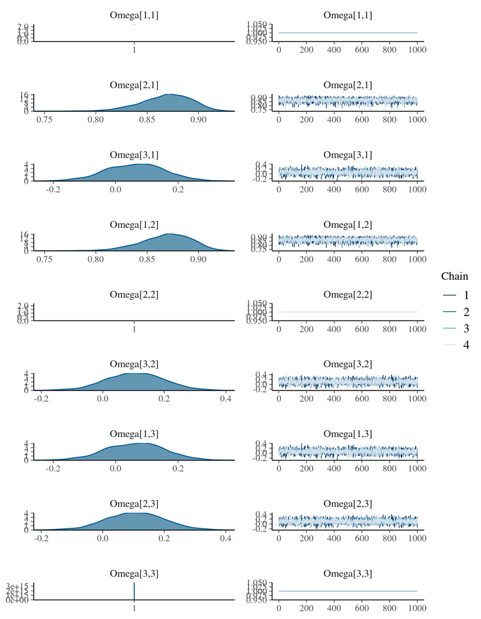

```r
rrho <- extract( mdlCor5 , pars = "Omega")$Omega
x_rho <- rrho[ , 2:3, 1]# cor(x,y) and cor(x,z)
y_rho <- rrho[ ,   3, 2]# cor(y,z)

out <- as.data.frame(cbind(x_rho, y_rho))
colnames(out) <- c("cor(x,y)", "cor(x,z)", "cor(y,z)")

rho_logspl <- apply(out, 2, logspline)
## to understand what is eta and why we are computing it in this way,
## see some lines above where it is written
## about the LKJ distribution
## eta        <- 3 + 1 - ncol(dat)/2
BF10       <- lapply(rho_logspl,
                     FUN = function(x, eta){
                       dbeta(0.5, eta, eta) / dlogspline(0 , x)
                       },
                     eta = 3 + 1 - ncol(dat)/2
                     )

kable(do.call("c", BF10), digits = 2, caption = "The Savage-Dickey BFs")
```

The Savage-Dickey BFs

|  | x |
| --- | --- |
| cor(x,y) | 1.583335e+21 |
| cor(x,z) | 5.200000e-01 |
| cor(y,z) | 7.700000e-01 |

[Download the Stan code](https://github.com/michelescandola/BayesianCorrelations/blob/main/multiple_correlation)

Do not worry for the NaNs in the summary of the posterior distribution.

This is normal when a variable in a MCMC takes always the same value, in this case 1, because it is the correlation between a values and itself.

Remember that in the Omega matrix 1 is the `x` variable, 2 the `y` and 3 the `z` one.

## The Bayesian Robust Correlation: multiple correlations

So let’s try to use a Student’s t-test distribution.

Because there is not a “cholensky” version of the multi Student’s t distribution, we should use the normal one, by passing as a parameter the covariance matrix.

For this reason, the correlation and covariance matrices are now computed in the transformed parameters block.

```r
stancode6 <- "
data {
    int<lower=1> N;  // number of observations
    int<lower=2> V;  // number of variables
    vector[V] x[N];  // input data: rows are observations, columns are the V variables
}

parameters {
    vector[V] mu;                           // locations of the normal distributions
    vector<lower=0>[V] sigma;               // scales of the normal distributions
    cholesky_factor_corr[V] Lrho;           // correlation matrix
}

transformed parameters {
    matrix[V,V] Omega;
    matrix[V,V] cov;
    // degrees of freedom of the marginal t distributions
    real<lower=1> nu = (N / 10.0) + 1;

    // Correlation and Covariance matrices
    Omega = multiply_lower_tri_self_transpose(Lrho);
    cov   = quad_form_diag(Omega, sigma);
}

model {
    // Noninformative priors on all parameters
    target += uniform_lpdf(sigma | 0, 10);
    target += normal_lpdf(mu | 0, 10);
    target += lkj_corr_cholesky_lpdf(Lrho| 3);

    // Likelihood
    // Multivariate Student's t distribution
    target += multi_student_t_lpdf(x | nu, mu, cov);
}

generated quantities {
  vector[V] x_rand;

  x_rand = multi_student_t_rng(nu, mu, cov);
}
"

mdlCor6 <- stan(
  model_code = stancode6,
  data = data.list,
  pars = "Omega",
  refresh = 0
)
```

```
## Trying to compile a simple C file
```

[output not shown]

```r
kable( summary(mdlCor6)[[1]] , digits = 3,
       caption = "Posterior distribution for the rho parameters (Omega matrix)")
```

Posterior distribution for the rho parameters (Omega matrix)

|  | mean | se_mean | sd | 2.5% | 25% | 50% | 75% | 97.5% | n_eff | Rhat |
| --- | --- | --- | --- | --- | --- | --- | --- | --- | --- | --- |
| Omega[1,1] | 1.000 | NaN | 0.000 | 1.000 | 1.000 | 1.000 | 1.000 | 1.000 | NaN | NaN |
| Omega[1,2] | 0.863 | 0.000 | 0.027 | 0.803 | 0.846 | 0.866 | 0.882 | 0.909 | 3155.376 | 1.000 |
| Omega[1,3] | 0.094 | 0.002 | 0.100 | -0.101 | 0.029 | 0.094 | 0.160 | 0.286 | 4016.328 | 0.999 |
| Omega[2,1] | 0.863 | 0.000 | 0.027 | 0.803 | 0.846 | 0.866 | 0.882 | 0.909 | 3155.376 | 1.000 |
| Omega[2,2] | 1.000 | NaN | 0.000 | 1.000 | 1.000 | 1.000 | 1.000 | 1.000 | NaN | NaN |
| Omega[2,3] | 0.130 | 0.002 | 0.099 | -0.065 | 0.062 | 0.131 | 0.196 | 0.323 | 4304.939 | 0.999 |
| Omega[3,1] | 0.094 | 0.002 | 0.100 | -0.101 | 0.029 | 0.094 | 0.160 | 0.286 | 4016.328 | 0.999 |
| Omega[3,2] | 0.130 | 0.002 | 0.099 | -0.065 | 0.062 | 0.131 | 0.196 | 0.323 | 4304.939 | 0.999 |
| Omega[3,3] | 1.000 | 0.000 | 0.000 | 1.000 | 1.000 | 1.000 | 1.000 | 1.000 | 3894.519 | 0.999 |
| lp__ | -644.844 | 0.052 | 2.151 | -649.951 | -646.086 | -644.445 | -643.278 | -641.624 | 1737.786 | 1.000 |

```r
mcmc_combo(
  mdlCor6,
  regex_pars = "Omega"
)
```

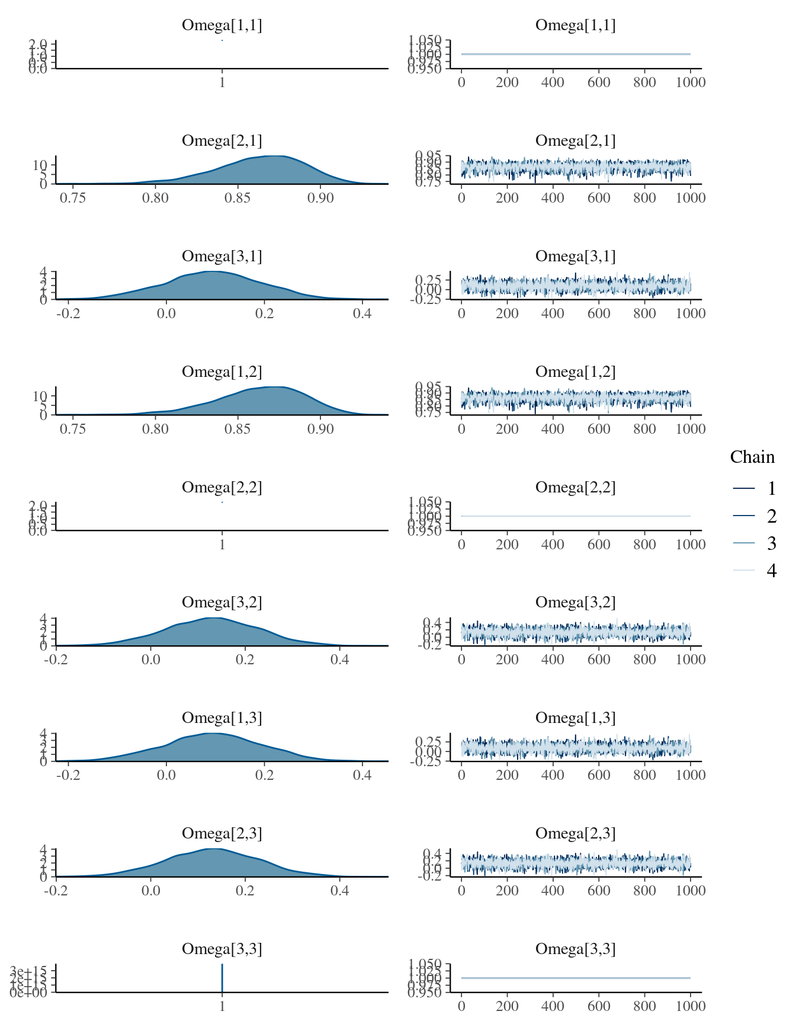

```r
rrho <- extract( mdlCor6 , pars = "Omega")$Omega
x_rho <- rrho[ , 2:3, 1]# cor(x,y) and cor(x,z)
y_rho <- rrho[ ,   3, 2]# cor(y,z)

out <- as.data.frame(cbind(x_rho, y_rho))
colnames(out) <- c("cor(x,y)", "cor(x,z)", "cor(y,z)")

rho_logspl <- apply(out, 2, logspline)

BF10       <- lapply(rho_logspl,
                     FUN = function(x, eta){
                       dbeta(0.5, eta, eta) / dlogspline(0 , x)
                       },
                     eta = 3 + 1 - ncol(dat)/2
                     )

kable(do.call("c", BF10), digits = 2, caption = "The Savage-Dickey BFs")
```

The Savage-Dickey BFs

|  | x |
| --- | --- |
| cor(x,y) | 1.046782e+22 |
| cor(x,z) | 6.500000e-01 |
| cor(y,z) | 1.020000e+00 |

[Download the Stan code](https://github.com/michelescandola/BayesianCorrelations/blob/main/robust_multiple_correlation_dog_from_sample_size_informative_prior.stan)

## Conclusions

We have seen how to compute Bayesian correlations using Stan.

What we are actually doing, is to model a covariance matrix among all the observed variables, and extracting the correlations from it.

I have spent a little time in explaining what to do for using robust correlations (that do not have an equivalent in the frequentist framework), how to compute Savage-Dickey ratios from them, and how to use this framework for multiple correlations.

Actually, the versions for multiple correlations are faster than the versions for the correlations between two only variables, because they are not using ugly conversions of the $\mathcal{B}(\alpha,\beta)$ distribution, but they use the more convenient LKJ distributions.

If you are not interested in computing the Savage-Dickey ratio, and you would like to have a non-informative distribution for the correlations (i.e., $\mathcal{U}(-1, 1)$), you just need to change `target += lkj_corr_cholesky_lpdf(Lrho| 3);` in `target += lkj_corr_cholesky_lpdf(Lrho| 1);`, that is equivalent to $\mathcal{U}(-1, 1)$, but more powerful.

## Would you like to learn something more about Bayesian Statistics?

There are a lot of excellent books and tutorials online, but if you want to have an overall overview of the main aspects, you might be interested in a Summer School, such as the **[BayesHSC Summer School](https://sites.hss.univr.it/bayeshsc/)** that will be held on-line or in Verona, from May $31^{st}$ to June $5^{th}$, 2021.

We are looking forward for you!